# Housing Prices

Cody Overholt

11/20/2021

## Background

This analysis was an exploration into housing prices in Ames, Iowa. The data included 79 explanatory variables that all held relevant information on the sale price of houses. The purpose was to showcase my ability to use information and tease out patterns found within the data.

## Model Summary

```r
summary(lm1) %>% pander()
```

|  | Estimate | Std. Error | t value | Pr(>\|t\|) |
| --- | --- | --- | --- | --- |
| **(Intercept)** | -60612 | 10286 | -5.893 | 5.384e-09 |
| **TotalSF** | 111.7 | 6.507 | 17.16 | 2.996e-57 |
| **I(TotalSF^2)** | -0.004844 | 0.001032 | -4.696 | 3.078e-06 |
| **SaleCondition2Normal** | 22129 | 5051 | 4.381 | 1.323e-05 |
| **SaleCondition2Other** | 5438 | 9620 | 0.5653 | 0.572 |
| **SaleCondition2Partial** | 52261 | 6697 | 7.804 | 1.68e-14 |
| **I(TotalSF^2):QualRankLow** | -0.0124 | 0.001216 | -10.19 | 3.676e-23 |
| **I(TotalSF^2):QualRankMed** | -0.006108 | 0.000383 | -15.95 | 1.407e-50 |

Fitting linear model: SalePrice ~ TotalSF + I(TotalSF^2) + I(TotalSF^2):QualRank + SaleCondition2

| Observations | Residual Std. Error | $R^2$ | Adjusted $R^2$ |
| --- | --- | --- | --- |
| 900 | 38934 | 0.7675 | 0.7657 |

I started by taking the total square footage and plotting it against the sale price. There was a clear upward trend that looked exponential save for two points on the right side of the graph. I followed up with checking the quality of the houses upon sale. The houses were ranked on a scale from 1-10. Individually, the rankings didn’t have a significant impact on the price. I then Binned the ranks into Low (1-4), Medium (5-7), and High (8-10) Quality houses. The groupings here were much more significant in their impact on the price as shown on the graph below. Higher quality houses typically yielded a higher sale price.

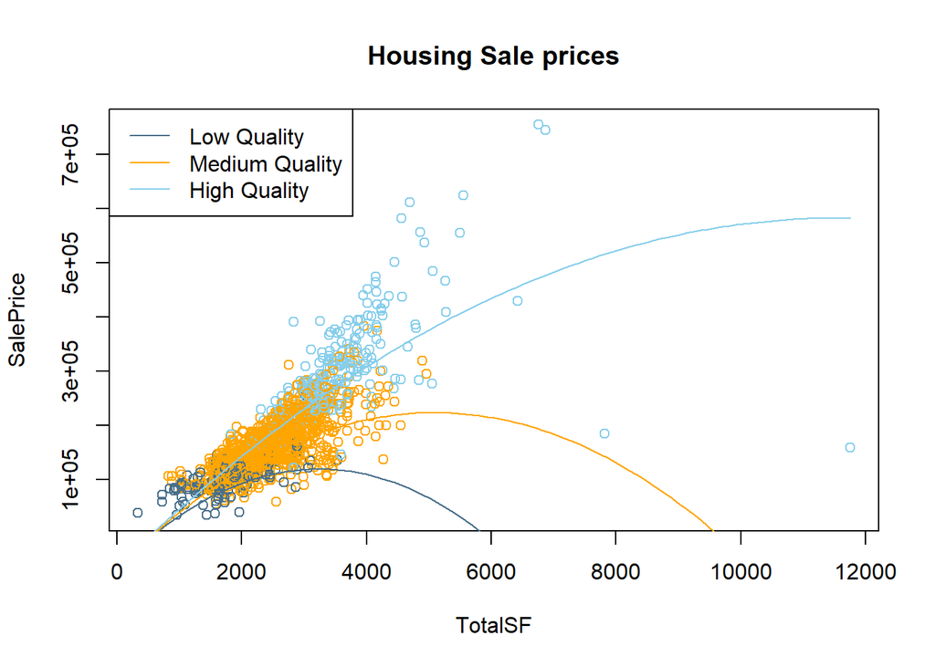

```r
palette(c("skyblue","skyblue4","orange","orangered", "firebrick", "firebrick4", "green", "limegreen"))
plot(SalePrice~TotalSF, data = mytrain1, col = QualRank, main= "Housing Sale prices")
curve(b['(Intercept)'] + b["TotalSF"]*x+b["I(TotalSF^2)"]*x^2, add = TRUE, col = palette()[1])
curve((b['(Intercept)']) +
        (b["TotalSF"])*x+
        (b["I(TotalSF^2)"]+b['I(TotalSF^2):QualRankLow']) *x^2, add = TRUE, col = palette()[2])
curve((b['(Intercept)']) +
        (b["TotalSF"])*x+
        (b["I(TotalSF^2)"]+b['I(TotalSF^2):QualRankMed']) *x^2, add = TRUE, col = palette()[3])
legend(x="topleft", legend = c("Low Quality", "Medium Quality", "High Quality"),
       col = c(2,3,1),
       lty=1)
```

Second, I looked at the affects of the type of sale on the price. I noticed that the two outliers on this scale were both partially completed in their construction when evaluated/sold. This only increased the R^2 by .01, but was still significant between most sale type. The only ones that didn’t show any significant impact were property mergers and sales within family. Binning these together into a single “Other” category didn’t change their significance. This is likely due to the fact there were less than 100 observations that fit into this “Other” category.

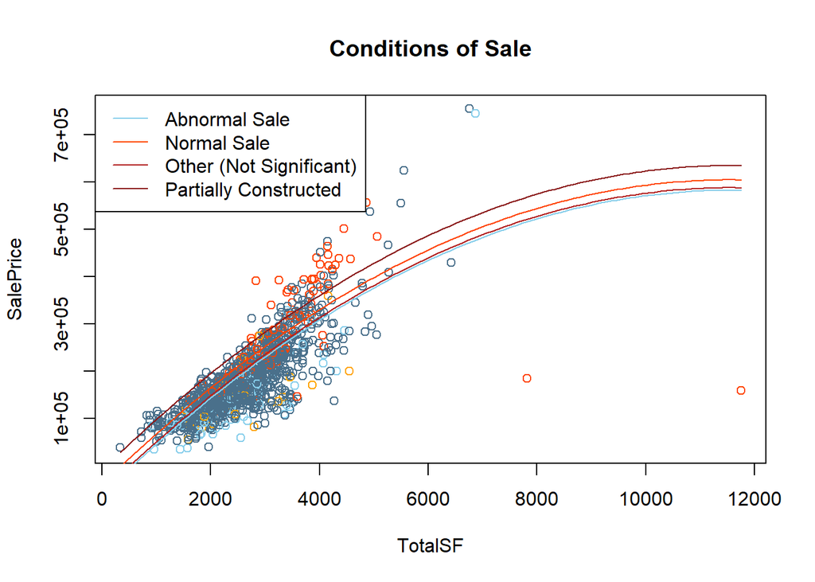

```r
plot(SalePrice~TotalSF, data = mytrain1, col = SaleCondition2, main = "Conditions of Sale")
curve(b['(Intercept)'] + b["TotalSF"]*x+b["I(TotalSF^2)"]*x^2, add = TRUE, col = palette()[1])
curve((b['(Intercept)']+b["SaleCondition2Normal"]) +
        (b["TotalSF"])*x+
        (b["I(TotalSF^2)"]) *x^2, add = TRUE, col = palette()[4])
curve((b['(Intercept)']+b["SaleCondition2Other"]) +
        (b["TotalSF"])*x+
        (b["I(TotalSF^2)"]) *x^2, add = TRUE, col = palette()[5])
curve((b['(Intercept)']+b["SaleCondition2Partial"]) +
        (b["TotalSF"])*x+
        (b["I(TotalSF^2)"]) *x^2, add = TRUE, col = palette()[6])
legend(x="topleft", legend = c("Abnormal Sale", "Normal Sale","Other (Not Significant)",  "Partially Constructed"),
       col = c(1,4,5,6),
       lty=1)
```

## Conclusion

By this point I had run out of time for further analysis. My end result validated with an Adjusted R^2 of .729. If I had more time to explore, I would continue to look at other variables to include and expand the model to 3 or more dimensions.

```r
  ##### Validation Code
yhat <- predict(lm1, newdata=my_test)
# Compute y-bar
ybar <- mean(my_test$SalePrice) #Yi is given by Ynew from the new sample of data

# Compute SSTO
SSTO <- sum( (my_test$SalePrice - ybar)^2 )


SSE <- sum( (my_test$SalePrice - yhat)^2 )


rsActual <- 1-SSE/SSTO

n <- length(my_test$SalePrice) #sample size

pActual <- length(coef(lm1))

rsAa <- 1 - (n-1)/(n-pActual)*SSE/SSTO

my_output_table2 <- data.frame(Model = c("Actual"), `Original R2` = c(summary(lm1)$r.squared), `Orig. Adj. R-squared` = c(summary(lm1)$adj.r.squared), `Validation R-squared` = c(rsActual), `Validation Adj. R^2` = c(rsAa))


  colnames(my_output_table2) <- c("Model", "Original $R^2$", "Original Adj. $R^2$", "Validation $R^2$", "Validation Adj. $R^2$")

  knitr::kable(my_output_table2, escape=TRUE, digits=4)
```

| Model | Original $R^2$ | Original Adj. $R^2$ | Validation $R^2$ | Validation Adj. $R^2$ |
| --- | --- | --- | --- | --- |
| Actual | 0.7675 | 0.7657 | 0.7324 | 0.729 |